# ZUM Projekt

## Opis projektu

**Temat projektu:** Nienadzorowana detekcja anomalii za lasu izolacyjnego. Funkcje do tworzenia modelu i predykcji. Porównanie z nadzorowaną detekcją anomalii za pomocą dostępnych w R algorytmów klasyfikacji.

## Struktura katalogów w projekcie przedstawia się nastepująco:

- **data** - katalog przechowyjący dane wejściowy
- **info** - katalog przechowujący sprawozdanie porjektu
- **src** - katalog przechowujący kod żrodłowy
- **isolation_forest.Rmd** - główny plik (notatnik) zawierajcy kod źródłowy
- **isolation_forest.html** - plik wynikowy generowany na podstawie isolation_forest.Rmd

## Wymagane biblioteki na potrzeby projektu

```r
library(ggplot2)
library(solitude)
library(R.matlab)
library(class)
library(caret)
library(e1071)
library(randomForest)
library(dbscan)
# need for confusedMatrix
#install.packages('e1071', dependencies=)

source("src/IsolationForest.R")
```

### Przygotowanie danych

- load_mat_data - wczytuje dane z pliku o formacie .mat do tabeli
- load_data - wczytuje dane z pliku do tabeli (data frame-u) w formacie innych niż *.mat
- print_mat_data_info - funkcja wypisująca informacja o plikach formatu *.mat.

```r
load_mat_data <- function(path) {
  return(readMat(path))
}

load_data <- function(path) {
  return(read.table(path, sep = ",", header = ))
}

prepare_mat_data <- function(mat_data) {
  df <- data.frame(mat_data$X)
  return(cbind(label = mat_data$y, df))
}

print_data_info <- function(data_df, file_name) {
  print(paste("Information for file:", file_name))
  outliers_num <- nrow(data_df[data_df$label == 1,])
  print(paste("Ilość danych N: ", nrow(data_df), ", Liczba parametrów M: ", ncol(data_df) - 1, ", Liczba ouliers: ", outliers_num, sep=""))
}

mat_to_df <- function(file_name) {
  data <- load_mat_data(file_name)
  data_df <- prepare_mat_data(data)
  print_data_info(data_df, file_name)

  return(data_df)
}
```

### Wczytywanie danych

Dane wzięty ze strony [Outlier Detection DataSets (ODDS)](http://odds.cs.stonybrook.edu/) oraz [Kaggle](https://www.kaggle.com/)

1. Credit Card Fraud Detection (Kaggle) [link](https://www.kaggle.com/mlg-ulb/creditcardfraud)
2. Arrhythmia dataset (ODDS) [link](http://odds.cs.stonybrook.edu/arrhythmia-dataset/)
3. http (KDDCUP99) dataset (ODDS) [link](http://odds.cs.stonybrook.edu/http-kddcup99-dataset/)
4. [Temporary] kddcup.data_10_percent_corrected - Zbiór danych obejmuje szeroką gamę ???włamań??? symulowanych w wojskowym środowisku sieciowym. [link](http://kdd.ics.uci.edu/databases/kddcup99/kddcup99.html)

#### Wczytywania danych z pliku arrhythmia.mat:

**Opis danych.** Dane składają się z dwóch tabel X i Y:

- X - to wielowymiarowe dane punktowe rozmiaru **N x M**, gdzie N - to liczba punkt, a M - to liczba cech.
- Y - to zbior etykiety o rozmiarze N (liczby punktów), oznaczajczy czy dany punkt jest wartością odstającą (1 = outliers, 0 = inliers)

```r
arrhythmia_data_df <- mat_to_df("data/arrhythmia.mat")
```

```
[1] "Information for file: data/arrhythmia.mat"
[1] "Ilosc danych N: 452, Liczba parametrów M: 274, Liczba ouliers: 66"
```

#### Wczytywania danych z pliku http.mat:

**Opis danych.** Dane składają się z dwóch tabel X i Y:

- X - to wielowymiarowe dane punktowe rozmiaru **N x M**, gdzie N - to liczba punkt, a M - to liczba cech.
- Y - to zbior etykiety o rozmiarze N (liczby punktów), oznaczajczy czy dany punkt jest wartością odstającą (1 = outliers, 0 = inliers)

```r
# [TODO] problem with open http.mat:
#   Error in readMat5(con, firstFourBytes = firstFourBytes, maxLength = maxLength) :
#   Reading of MAT v7.3 files is not supported. If possible, save the data in MATLAB using 'save -V6'.

# Uncomment these lines  when the problem is resolved.
# http_data <- load_mat_data("data/http.mat")
# http_data_df <- prepare_mat_data(http_data)
# print_mat_data_info(http_data)
```

#### Wczytywania danych z pliku creditcard.csv:

**Opis danych**:

Zbiór danych zawiera transakcje dokonane kartami kredytowymi we wrześniu 2013 r. przez europejskich posiadaczy kart. Ten zbiór danych przedstawia transakcje, które miały miejsce w ciągu dwóch dni, w których mamy **492 oszustw** z 284 807 transakcji.

Dane przedstawione za pomocą tabeli o rozmiarze **N x M** gdzie:

- N - ilość transakcyj
- M - liczba cech, których jest 31

Cechy:

1. Ze względu na to, że oryganalnych danych nie można udostępnić, ze względu zabiezpieczęnie danych użytkownika, to mama doczynienia z danymi, które są wynikem redukcji wymiarowości za pomocą PCA (angl. *Principal Component Analysis*).Te cechy w tabele przedstawione jako V1, V2, V3, … , V28.
2. Time - zawiera liczba sekund która upłynęła między każdą transakcją a pierwszą transakcją w zbiorze danych.
3. Amount - to kwota transakcji.
4. class - przejmuję wartość 1 gdy transakcja jest oszustwej (outliers) i 0 w przeciwnym przypadku.

```r
# TODO some problem with open File, Temporary comment this
#creditcard_data <- load_data("data/creditcard.csv")
#head(creditcard_data)
```

### Metryki do sprawdzenia wyników

- **split_data_to_train_and_test** - podział zbioru danych na uczący i testowy
- **run_evaluation_metrics** - wyświetelenie macierz błędów (angl. *Confusion matrix*), Recall oraz Precision

```r
split_data_to_train_and_test <- function(df, persent_split) {
  smp_size <- floor(persent_split * nrow(df))
  ## ustałiam tą wartość, żeby podział był ten samy za kązdym razem
  #set.seed(123)
  set.seed(.Random.seed)
  train_ind <- sample(seq_len(nrow(df)), size = smp_size)
  train <- df[train_ind, ]
  test <- df[-train_ind, ]
  train_no_label <- train[,2:ncol(train)]
  test_no_label <- test[,2:ncol(test)]
  train_label <- train[,1]
  return(list(train=train, test=test, train_no_label=train_no_label, test_no_label=test_no_label, train_label=train_label))
}

run_evaluation_metrics <- function(pred, expected) {
  precision <- posPredValue(pred, expected)
  recall <- sensitivity(pred, expected)
  conf <- confusionMatrix(pred, expected)
  print(paste("precision: ", precision))
  print(paste("recall: ", recall))
  print(conf)
  return(list(precision=round(precision, 4), recall=round(recall, 4), accuracy=round(conf$overall[1], 4)))
}

result_evaluation_list <- list()
```

### **ETAP 1** Sprawdzenie działania algorytmu na sztucznym zbiorze danych oraz publiczne dostępnych zbiorach

```r
source("src/IsolationForest.R")
test_mnist_data_df <- mat_to_df("data/temporary/mnist.mat")
```

```
[1] "Information for file: data/temporary/mnist.mat"
[1] "Ilosc danych N: 7603, Liczba parametrów M: 100, Liczba ouliers: 700"
```

```r
split_train_test_df <- split_data_to_train_and_test(test_mnist_data_df, 0.8)
split_df <- split_train_test_df
iforest <- IsolationForest$new()
fit <- iforest$fit(split_df$train_no_label, 5)
pred <- factor(iforest$predict(split_df$train_no_label))
expected <-  factor(split_train_test_df$train_label)

run_evaluation_metrics(pred, expected)
```

```
[1] "precision:  0.914203833064661"
[1] "recall:  0.923132573702297"
Confusion Matrix and Statistics

          Reference
Prediction    0    1
         0 5104  479
         1  425   74

               Accuracy : 0.8514
                 95% CI : (0.8422, 0.8602)
    No Information Rate : 0.9091
    P-Value [Acc > NIR] : 1.00000

                  Kappa : 0.0596

 Mcnemar's Test P-Value : 0.07794

            Sensitivity : 0.9231
            Specificity : 0.1338
         Pos Pred Value : 0.9142
         Neg Pred Value : 0.1483
             Prevalence : 0.9091
         Detection Rate : 0.8392
   Detection Prevalence : 0.9180
      Balanced Accuracy : 0.5285

       'Positive' Class : 0

$precision
[1] 0.9142

$recall
[1] 0.9231

$accuracy
Accuracy
  0.8514
```

```r
pred
```

[output not shown]

```r
# to remove this note it's just to test
library(ggplot2)
library(solitude)

#create and plot sample data
run_isolation_forest <- function(split_df, k=10) {
  iforest<- isolationForest$new()
  iforest$fit(split_df$train_no_label)
  pred <- iforest$predict(split_df$test_no_label)
  return(ifelse(pred$anomaly_score >=0.60, 1, 0))
}

split_train_test_df <- split_data_to_train_and_test(arrhythmia_data_df, 0.8)

#create isolation forest using isolationForest function from solitude package with default parameters
iforest<- isolationForest$new()
iforest$fit(split_train_test_df$train_no_label)
```

```
INFO  [22:22:13.825] Building Isolation Forest ...
INFO  [22:22:14.174] done
INFO  [22:22:14.177] Computing depth of terminal nodes ...
INFO  [22:22:14.423] done
INFO  [22:22:14.448] Completed growing isolation forest
```

```r
pred <- iforest$predict(split_train_test_df$test_no_label)
pred$label <- as.factor(ifelse(pred$anomaly_score >=0.60, 1, 0))

expected <-  factor(split_train_test_df$test[,1])

# Evaluation
run_evaluation_metrics(pred$label, expected)
```

```
[1] "precision:  0.893939393939394"
[1] "recall:  0.786666666666667"
Confusion Matrix and Statistics

          Reference
Prediction  0  1
         0 59  7
         1 16  9

               Accuracy : 0.7473
                 95% CI : (0.6453, 0.8325)
    No Information Rate : 0.8242
    P-Value [Acc > NIR] : 0.97655

                  Kappa : 0.2859

 Mcnemar's Test P-Value : 0.09529

            Sensitivity : 0.7867
            Specificity : 0.5625
         Pos Pred Value : 0.8939
         Neg Pred Value : 0.3600
             Prevalence : 0.8242
         Detection Rate : 0.6484
   Detection Prevalence : 0.7253
      Balanced Accuracy : 0.6746

       'Positive' Class : 0

$precision
[1] 0.8939

$recall
[1] 0.7867

$accuracy
Accuracy
  0.7473
```

### **ETAP 3** Badanie działania algorytmu z innymi dostępnymi w języku R metodami detekcji wartości odstających, takich jak:

1. K najbliższych sąsiadów (angl.*k-nearest neighbors*)
2. Klasyfikacja jednoklasowa (angl. *One-class SVM*)
3. Lokalny współczynnik wyjątkowości (angl. *Local outlier factor*)
4. Las losowy (angl. *Random Forests*)

#### 1. K najbliższych sąsiadów

```r
run_knn <- function(split_df, k=10) {
  train <- split_df$train
  test <- split_df$test

  return(knn(train=split_df$train_no_label, test=split_df$test_no_label, cl=split_df$train_label, k=k))
}
```

#### 2. Klasyfikacja jednoklasowa

```r
run_one_class_svm <- function(split_df) {

  # training
  model <- svm(x=split_df$train_no_label, y=split_df$trainlabel, type='one-classification',kernel='linear')
  pred <- predict(model, split_df$test_no_label)

  # prepare result
  pred_df <- data.frame(pred)
  pred_df$pred[pred_df$pred== "TRUE"] <- 1
  pred_df$pred[pred_df$pred== "FALSE"] <- 0

  return(pred_df$pred)
}
```

#### 3. Lokalny współczynnik wyjątkowości

```r
split_train_test_df <- split_data_to_train_and_test(arrhythmia_data_df, 0.8)
lof <- lof(split_train_test_df$train_no_label, minPts = 3)
```

#### 4. Las losowy

Specyfikacji odnośnie funkcji randomForest [Link Random Forest](https://www.rdocumentation.org/packages/randomForest/versions/4.6-14/topics/randomForest)

```r
run_random_forest <- function(split_df) {

  rf_classifier <- randomForest(x=split_df$train_no_label, y=split_df$train_label, ntree=100, mtry=2, importance=TRUE)
  prediction_for_table <- predict(rf_classifier, split_df$test_no_label)

  # prepare result
  pred_df <- data.frame(pred=prediction_for_table)
  pred_df$pred[pred_df$pred >= 0.5] <- 1
  pred_df$pred[pred_df$pred <  0.5] <- 0

  return(pred_df$pred)
}
```

*run_algorithm_and_print_result* - funkcja uruchamiająca wybrany algorytm o wybranych parametrach:

1. *data_df* - dane wejściowe
2. *name_of_algo* - algorytm który ma zadziałać
3. *split_factor* - procent danych uczących się

```r
KNN_algo = "KNN"
ONE_SVM_algo = "One-SVM"
LOF_algo = "LOF"
RF_algo = "Random Forest"
IF_algo = "Isolation Forest"

run_algorithm_and_print_result <- function(data_df, test_data_name, name_of_algo, df_result, split_factor=0.8) {
  start.time <- Sys.time()
  split_train_test_df <- split_data_to_train_and_test(data_df, 0.8)

  expected <-  factor(split_train_test_df$test[,1])
  pred = switch(
    name_of_algo,
    "KNN" = factor(run_knn(split_train_test_df)),
    "One-SVM"=factor(run_one_class_svm(split_train_test_df)),
    "LOF"=factor(run_random_forest(split_train_test_df)),
    "Random Forest"=factor(run_random_forest(split_train_test_df)),
    "Isolation Forest"=factor(run_isolation_forest(split_train_test_df))
   )
  end.time <- Sys.time()
  time.taken <- round(end.time - start.time, 4)
  result_eval = run_evaluation_metrics(pred, expected)

  return(c(test_data_name, name_of_algo, time.taken, result_eval$precision, result_eval$recall, result_eval$accuracy))
}
```

### [TODO] Dany rozdział do usunięcia:

```r
test_satellite_data_df <- mat_to_df("data/temporary/satellite.mat")
```

```
[1] "Information for file: data/temporary/satellite.mat"
[1] "Ilosc danych N: 6435, Liczba parametrów M: 36, Liczba ouliers: 2036"
```

```r
test_cover_data_df <- mat_to_df("data/temporary/cover.mat")
```

```
[1] "Information for file: data/temporary/cover.mat"
[1] "Ilosc danych N: 286048, Liczba parametrów M: 10, Liczba ouliers: 2747"
```

```r
test_mnist_data_df <- mat_to_df("data/temporary/mnist.mat")
```

```
[1] "Information for file: data/temporary/mnist.mat"
[1] "Ilosc danych N: 7603, Liczba parametrów M: 100, Liczba ouliers: 700"
```

```r
# Zbieramy tutaj dane
name_of_cols = c("test_data_name", "algo", "execution_time","precision", "recall", "accuracy")
df_with_metrics <- data.frame(matrix(ncol = 6, nrow = 0))
df_with_metrics <- setNames(df_with_metrics, name_of_cols)

df_with_metrics[nrow(df_with_metrics) + 1,] = run_algorithm_and_print_result(test_mnist_data_df, "mnist", IF_algo, df_with_metrics)
```

```
INFO  [22:22:15.634] Building Isolation Forest ...
INFO  [22:22:15.844] done
INFO  [22:22:15.847] Computing depth of terminal nodes ...
INFO  [22:22:16.125] done
INFO  [22:22:16.359] Completed growing isolation forest
[1] "precision:  0.946564885496183"
[1] "recall:  0.72197962154294"
Confusion Matrix and Statistics

          Reference
Prediction   0   1
         0 992  56
         1 382  91

               Accuracy : 0.712
                 95% CI : (0.6886, 0.7347)
    No Information Rate : 0.9034
    P-Value [Acc > NIR] : 1

                  Kappa : 0.1714

 Mcnemar's Test P-Value : <2e-16

            Sensitivity : 0.7220
            Specificity : 0.6190
         Pos Pred Value : 0.9466
         Neg Pred Value : 0.1924
             Prevalence : 0.9034
         Detection Rate : 0.6522
   Detection Prevalence : 0.6890
      Balanced Accuracy : 0.6705

       'Positive' Class : 0
```

```r
df_with_metrics
```

|  | test_data_name | algo | execution_time | precision | recall | accuracy |
| --- | --- | --- | --- | --- | --- | --- |
| 1 | mnist | Isolation Forest | 1.1079 | 0.9466 | 0.722 | 0.712 |

```r
#alist <- list(a="a", b="b")
#blist <- list(alist=alist, a="c", b="d")
#blist$alist$a
#listres <- list(alist, blist)
#res_mat <- matrix(unlist(listres),ncol=2,byrow=TRUE)
```

Test czasu

```r
range = 4
df_with_metrics <- data.frame(matrix(ncol = 6, nrow = 0))
df_with_metrics <- setNames(df_with_metrics, name_of_cols)

for(i in 1:range) {
  df_with_metrics[nrow(df_with_metrics) + 1,] = run_algorithm_and_print_result(test_mnist_data_df, "mnist", IF_algo, df_with_metrics)

}
```

```
INFO  [22:28:44.979] Building Isolation Forest ...
INFO  [22:28:45.246] done
INFO  [22:28:45.250] Computing depth of terminal nodes ...
INFO  [22:28:45.457] done
INFO  [22:28:45.650] Completed growing isolation forest
[1] "precision:  0.946564885496183"
[1] "recall:  0.72197962154294"
Confusion Matrix and Statistics

          Reference
Prediction   0   1
         0 992  56
         1 382  91

               Accuracy : 0.712
                 95% CI : (0.6886, 0.7347)
    No Information Rate : 0.9034
    P-Value [Acc > NIR] : 1

                  Kappa : 0.1714

 Mcnemar's Test P-Value : <2e-16

            Sensitivity : 0.7220
            Specificity : 0.6190
         Pos Pred Value : 0.9466
         Neg Pred Value : 0.1924
             Prevalence : 0.9034
         Detection Rate : 0.6522
   Detection Prevalence : 0.6890
      Balanced Accuracy : 0.6705

       'Positive' Class : 0

INFO  [22:28:46.073] Building Isolation Forest ...
INFO  [22:28:46.277] done
INFO  [22:28:46.280] Computing depth of terminal nodes ...
INFO  [22:28:46.494] done
INFO  [22:28:46.679] Completed growing isolation forest
[1] "precision:  0.946564885496183"
```

[output cut: 80 more lines]

```

                  Kappa : 0.1714

 Mcnemar's Test P-Value : <2e-16

            Sensitivity : 0.7220
            Specificity : 0.6190
         Pos Pred Value : 0.9466
         Neg Pred Value : 0.1924
             Prevalence : 0.9034
         Detection Rate : 0.6522
   Detection Prevalence : 0.6890
      Balanced Accuracy : 0.6705

       'Positive' Class : 0
```

```r
df_with_metrics
```

|  | test_data_name | algo | execution_time | precision | recall | accuracy |
| --- | --- | --- | --- | --- | --- | --- |
| 1 | mnist | Isolation Forest | 1.0399 | 0.9466 | 0.722 | 0.712 |
| 2 | mnist | Isolation Forest | 0.9823 | 0.9466 | 0.722 | 0.712 |
| 3 | mnist | Isolation Forest | 0.9928 | 0.9466 | 0.722 | 0.712 |
| 4 | mnist | Isolation Forest | 1.0394 | 0.9466 | 0.722 | 0.712 |

```r
library(caret)
library("plotROC")
# Train and evaluate

# Evaluation
run_evaluation_metrics(pred, expected)
```

[output not shown]

```r
# finish Train and evaluate

roc.estimate <- calculate_roc(pred, expected)
single.rocplot <- ggroc(roc.estimate)
```

```
ggroc is deprecated. Please use geom_roc instead. Type ?geom_roc for more information.
```

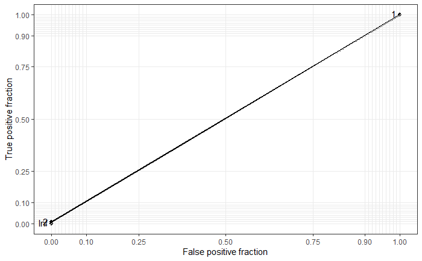

```r
plot_journal_roc(single.rocplot)
```

# Just for tests! [TO remove]

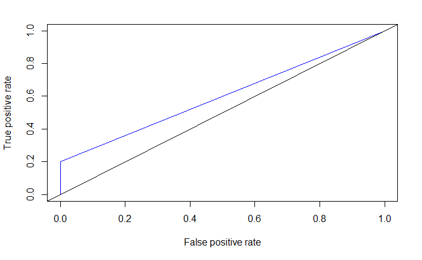

```r
library("ROCR")
pred_a <- prediction(c(pred), c(expected))
perf <- performance(pred_a, "tpr","fpr")
plot(perf,col="blue")

abline(0,1)
```